# DATA 607 - Assignment7 [Working with HTML, XML and JSON in R]

Simon63

March 18, 2018

# Working with books data in 3 formats

## HTML

**Here’s how a book with multiple authors looks like in HTML file**

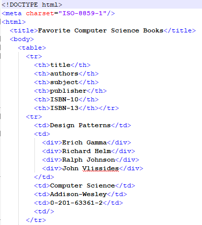

#### Package Installs

install.packages(“tidyverse”)  
install.packages(“XML”)

```r
library(tidyverse)
library(XML)
```

```r
path <- "https://raw.githubusercontent.com/simon63/Assignment7/master/books.html"
download.file(path, destfile = "~/books.html")
path <- file.path("books.html")
booksHtml <- htmlParse(path)
html_tb <- readHTMLTable(booksHtml, stringAsFactors = FALSE)
```

```r
df.html <- html_tb[[1]] %>% tbl_df()
df.html
```

```
## # A tibble: 3 x 6
##   title      authors              subject   publisher  `ISBN-10` `ISBN-13`
##   <fct>      <fct>                <fct>     <fct>      <fct>     <fct>
## 1 Design Pa~ "Erich Gamma\r\n\t\~ Computer~ Addison-W~ 0-201-63~ ""
## 2 Object-Or~ Arthur J. Riel       Computer~ Addison-W~ 0-201-63~ ""
## 3 SQL Cookb~ Anthony Molinaro     Computer~ O'Reilly   05960097~ 978-0596~
```

Viewing HTML data frame using **knir::kable** gives unexpected results  
due to multiple authors for a book

```r
knitr::kable(df.html)
```

| title | authors | subject | publisher | ISBN-10 | ISBN-13 |
| --- | --- | --- | --- | --- | --- |
| Design Patterns | Erich Gamma |  |  |  |  |
| Richard Helm |  |  |  |  |  |
| Ralph Johnson |  |  |  |  |  |
| John Vlissides Computer | Science Addison-Wesley 0-201-63361-2 |  |  |  |  |
| Object-Oriented Design Heuristics | Arthur J. Riel | Computer Science | Addison-Wesley | 0-201-63385-X |  |
| SQL Cookbook | Anthony Molinaro | Computer Science | O’Reilly | 0596009763 | 978-0596009762 |

The multiple authors are separated by **“\r\n\t\t”** sequence

```r
as.vector(df.html$authors)
```

```
## [1] "Erich Gamma\r\n\t\t  Richard Helm\r\n\t\t  Ralph Johnson\r\n\t\t  John Vlissides"
## [2] "Arthur J. Riel"
## [3] "Anthony Molinaro"
```

## XML

**Here’s how the books data looks like in XML file**

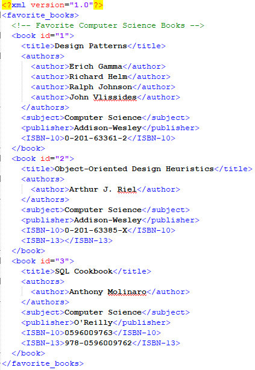

```r
path <- "https://raw.githubusercontent.com/simon63/Assignment7/master/books.xml"
download.file(path, destfile = "~/books.xml")
path <- file.path("books.xml")
booksXML <- xmlParse(path)
```

Examining XML root’s name, number of elements and the 1st element

```r
root <- xmlRoot(booksXML)
xmlName(root)
```

```
## [1] "favorite_books"
```

```r
xmlSize(root)
```

```
## [1] 4
```

```r
root[[1]]
```

```
## <!-- Favorite Computer Science Books -->
```

View 1st Book XML element

```r
root[["book"]]
```

```
## <book id="1">
##   <title>Design Patterns</title>
##   <authors>
##     <author>Erich Gamma</author>
##     <author>Richard Helm</author>
##     <author>Ralph Johnson</author>
##     <author>John Vlissides</author>
##   </authors>
##   <subject>Computer Science</subject>
##   <publisher>Addison-Wesley</publisher>
##   <ISBN-10>0-201-63361-2</ISBN-10>
## </book>
```

View all Book elements

```r
root["book"]
```

```
## $book
## <book id="1">
##   <title>Design Patterns</title>
##   <authors>
##     <author>Erich Gamma</author>
##     <author>Richard Helm</author>
##     <author>Ralph Johnson</author>
##     <author>John Vlissides</author>
##   </authors>
##   <subject>Computer Science</subject>
##   <publisher>Addison-Wesley</publisher>
##   <ISBN-10>0-201-63361-2</ISBN-10>
## </book>
##
## $book
## <book id="2">
##   <title>Object-Oriented Design Heuristics</title>
##   <authors>
##     <author>Arthur J. Riel</author>
##   </authors>
##   <subject>Computer Science</subject>
##   <publisher>Addison-Wesley</publisher>
##   <ISBN-10>0-201-63385-X</ISBN-10>
##   <ISBN-13/>
## </book>
##
## $book
## <book id="3">
##   <title>SQL Cookbook</title>
##   <authors>
##     <author>Anthony Molinaro</author>
##   </authors>
##   <subject>Computer Science</subject>
##   <publisher>O'Reilly</publisher>
##   <ISBN-10>0596009763</ISBN-10>
##   <ISBN-13>978-0596009762</ISBN-13>
## </book>
##
## attr(,"class")
## [1] "XMLInternalNodeList" "XMLNodeList"
```

Trying **xmlToDataFrame** function

```r
df.xml <- xmlToDataFrame(root, stringsAsFactors = F) %>% tbl_df()
df.xml
```

```
## # A tibble: 4 x 6
##   title        authors           subject   publisher  `ISBN-10` `ISBN-13`
##   <chr>        <chr>             <chr>     <chr>      <chr>     <chr>
## 1 <NA>         <NA>              <NA>      <NA>       <NA>      <NA>
## 2 Design Patt~ Erich GammaRicha~ Computer~ Addison-W~ 0-201-63~ <NA>
## 3 Object-Orie~ Arthur J. Riel    Computer~ Addison-W~ 0-201-63~ ""
## 4 SQL Cookbook Anthony Molinaro  Computer~ O'Reilly   05960097~ 978-05960~
```

*Obervations:*  
1. There is a blank row for the Comment line in XML  
2. Multiple Authors are concatenated without any separation (unlike the HTML-parsing case)  
3. Structure (in terms of columns) is similar to the HTML-parsing case

## JSON

**Here’s how the books data looks like in JSON file**

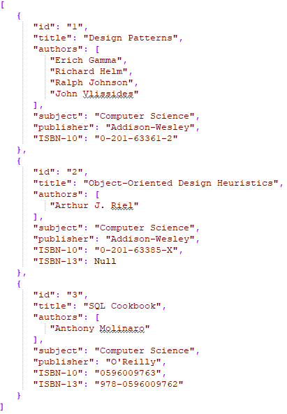

```r
library(RJSONIO)
```

Check if JSON file is valid

```r
path <- "https://raw.githubusercontent.com/simon63/Assignment7/master/books.json"
download.file(path, destfile = "~/books.json")
path <- file.path("books.json")
isValidJSON(path)
```

```
## [1] TRUE
```

Tryng **fromJSON()** function to parse the file

```r
booksJSON <- fromJSON(content = path)
class(booksJSON)
```

```
## [1] "list"
```

```r
glimpse(booksJSON)
```

```
## List of 3
##  $ :List of 6
##   ..$ id       : chr "1"
##   ..$ title    : chr "Design Patterns"
##   ..$ authors  : chr [1:4] "Erich Gamma" "Richard Helm" "Ralph Johnson" "John Vlissides"
##   ..$ subject  : chr "Computer Science"
##   ..$ publisher: chr "Addison-Wesley"
##   ..$ ISBN-10  : chr "0-201-63361-2"
##  $ :List of 7
##   ..$ id       : chr "2"
##   ..$ title    : chr "Object-Oriented Design Heuristics"
##   ..$ authors  : chr "Arthur J. Riel"
##   ..$ subject  : chr "Computer Science"
##   ..$ publisher: chr "Addison-Wesley"
##   ..$ ISBN-10  : chr "0-201-63385-X"
##   ..$ ISBN-13  : NULL
##  $ :List of 7
##   ..$ id       : chr "3"
##   ..$ title    : chr "SQL Cookbook"
##   ..$ authors  : chr "Anthony Molinaro"
##   ..$ subject  : chr "Computer Science"
##   ..$ publisher: chr "O'Reilly"
##   ..$ ISBN-10  : chr "0596009763"
##   ..$ ISBN-13  : chr "978-0596009762"
```

Trying to use **unlist()** function and extracting the book titles

```r
book.vec <- unlist(booksJSON, recursive = T, use.names = T)
names(book.vec)
```

```
##  [1] "id"        "title"     "authors1"  "authors2"  "authors3"
##  [6] "authors4"  "subject"   "publisher" "ISBN-10"   "id"
## [11] "title"     "authors"   "subject"   "publisher" "ISBN-10"
## [16] "id"        "title"     "authors"   "subject"   "publisher"
## [21] "ISBN-10"   "ISBN-13"
```

```r
book.vec[str_detect(names(book.vec), "title")]
```

```
##                               title                               title
##                   "Design Patterns" "Object-Oriented Design Heuristics"
##                               title
##                      "SQL Cookbook"
```

*Note:* The 4 Authors for book 1 got labeled as *“authors1”, “authors2”, “authors3”, “authors4”*

Converting each JSON book class into separate data frames  
using a combination of **lapply(), do.call() and rbind** functions

```r
do.call("rbind", lapply(booksJSON[[1]], data.frame, stringsAsFactors = F))
```

```
##                     X..i..
## id                       1
## title      Design Patterns
## authors.1      Erich Gamma
## authors.2     Richard Helm
## authors.3    Ralph Johnson
## authors.4   John Vlissides
## subject   Computer Science
## publisher   Addison-Wesley
## ISBN-10      0-201-63361-2
```

```r
do.call("rbind", lapply(booksJSON[[2]], data.frame, stringsAsFactors = F))
```

```
##                                      X..i..
## id                                        2
## title     Object-Oriented Design Heuristics
## authors                      Arthur J. Riel
## subject                    Computer Science
## publisher                    Addison-Wesley
## ISBN-10                       0-201-63385-X
```

```r
do.call("rbind", lapply(booksJSON[[3]], data.frame, stringsAsFactors = F))
```

```
##                     X..i..
## id                       3
## title         SQL Cookbook
## authors   Anthony Molinaro
## subject   Computer Science
## publisher         O'Reilly
## ISBN-10         0596009763
## ISBN-13     978-0596009762
```

*Note:* This provides 3 data frames with slightly different structures between each other

Now trying **jsonlite** package ####Package Installs install.packages(“jsonlite”)

```r
library(jsonlite)
```

Tryng **fromJSON()** function to parse the file

```r
booksJSON <- fromJSON(txt = path)
class(booksJSON)
glimpse(booksJSON)
```

Got “Error in parse_con” as the parser failed interpret ISBN field value

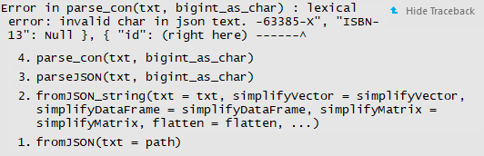

Trying with a different JSON file without the troubling ISBN value

```r
path <- "https://raw.githubusercontent.com/simon63/Assignment7/master/books-fix.json"
download.file(path, destfile = "~/books-fix.json")
path <- file.path("books-fix.json")
booksJSON <- fromJSON(txt = path)
class(booksJSON)
```

```
## [1] "data.frame"
```

```r
glimpse(booksJSON)
```

```
## Observations: 3
## Variables: 7
## $ id        <chr> "1", "2", "3"
## $ title     <chr> "Design Patterns", "Object-Oriented Design Heuristic...
## $ authors   <list> [<"Erich Gamma", "Richard Helm", "Ralph Johnson", "...
## $ subject   <chr> "Computer Science", "Computer Science", "Computer Sc...
## $ publisher <chr> "Addison-Wesley", "Addison-Wesley", "O'Reilly"
## $ `ISBN-10` <chr> "0-201-63361-2", NA, "0596009763"
## $ `ISBN-13` <chr> NA, NA, "978-0596009762"
```

*Conclusion* Using **jsonlite::fromJSON()** is convenient and gives a nice and expected data frame structure, **but** it seems to be very sensitive to and problematic with the textual representation of data values inside JSON files.